# **Problem Statement**

## Business Context

Renewable energy sources play an increasingly important role in the global energy mix, as the effort to reduce the environmental impact of energy production increases.

Out of all the renewable energy alternatives, wind energy is one of the most developed technologies worldwide. The U.S Department of Energy has put together a guide to achieving operational efficiency using predictive maintenance practices.

Predictive maintenance uses sensor information and analysis methods to measure and predict degradation and future component capability. The idea behind predictive maintenance is that failure patterns are predictable and if component failure can be predicted accurately and the component is replaced before it fails, the costs of operation and maintenance will be much lower.

The sensors fitted across different machines involved in the process of energy generation collect data related to various environmental factors (temperature, humidity, wind speed, etc.) and additional features related to various parts of the wind turbine (gearbox, tower, blades, break, etc.).

## Objective

“ReneWind” is a company working on improving the machinery/processes involved in the production of wind energy using machine learning and has collected data of generator failure of wind turbines using sensors. They have shared a ciphered version of the data, as the data collected through sensors is confidential (the type of data collected varies with companies). Data has 40 predictors, 20000 observations in the training set and 5000 in the test set.

The objective is to build various classification models, tune them, and find the best one that will help identify failures so that the generators could be repaired before failing/breaking to reduce the overall maintenance cost. The nature of predictions made by the classification model will translate as follows:

- True positives (TP) are failures correctly predicted by the model. These will result in repairing costs.
- False negatives (FN) are real failures where there is no detection by the model. These will result in replacement costs.
- False positives (FP) are detections where there is no failure. These will result in inspection costs.

It is given that the cost of repairing a generator is much less than the cost of replacing it, and the cost of inspection is less than the cost of repair.

“1” in the target variables should be considered as “failure” and “0” represents “No failure”.

## Data Description

The data provided is a transformed version of the original data which was collected using sensors.

- Train.csv - To be used for training and tuning of models.
- Test.csv - To be used only for testing the performance of the final best model.

Both the datasets consist of 40 predictor variables and 1 target variable.

# **Installing and Importing the necessary libraries**

```python
# Installing the libraries with the specified version
!pip install --no-deps tensorflow==2.18.0 scikit-learn==1.3.2 matplotlib===3.8.3 seaborn==0.13.2 numpy==1.26.4 pandas==2.2.2 -q --user --no-warn-script-location
```

```python
import warnings
warnings.filterwarnings('ignore')

import os, sys, math, json
import numpy as np
import pandas as pd

import matplotlib.pyplot as plt

from sklearn.model_selection import StratifiedKFold, cross_val_predict
from sklearn.compose import ColumnTransformer
from sklearn.pipeline import Pipeline
from sklearn.metrics import (confusion_matrix, classification_report, roc_auc_score, roc_curve,
                             precision_recall_curve, average_precision_score)
from sklearn.linear_model import LogisticRegression
from sklearn.ensemble import RandomForestClassifier, GradientBoostingClassifier

from collections import defaultdict

from google.colab import drive

import seaborn as sns
import tensorflow as tf
from tensorflow.keras.models import Sequential
from tensorflow.keras.layers import Dense
from tensorflow.keras.optimizers import SGD

from sklearn.model_selection import train_test_split
from sklearn.preprocessing import LabelEncoder, StandardScaler
from imblearn.over_sampling import SMOTE

from sklearn.metrics import accuracy_score, f1_score, RocCurveDisplay, precision_score, recall_score, confusion_matrix, classification_report, roc_auc_score
from tensorflow.keras.layers import Dropout
from sklearn.utils.class_weight import compute_class_weight
from tensorflow.keras.metrics import Recall, Precision

RANDOM_STATE = 42
np.random.seed(RANDOM_STATE)
```

**Note**:

- After running the above cell, kindly restart the runtime (for Google Colab) or notebook kernel (for Jupyter Notebook), and run all cells sequentially from the next cell.
- On executing the above line of code, you might see a warning regarding package dependencies. This error message can be ignored as the above code ensures that all necessary libraries and their dependencies are maintained to successfully execute the code in **this notebook**.

# **Loading the Data**

```python
drive.mount('/content/drive')

train_path = '/content/drive/My Drive/Colab Notebooks/Train.csv'
test_path  = '/content/drive/My Drive/Colab Notebooks/Test.csv'

train_df = pd.read_csv(train_path)
test_df  = pd.read_csv(test_path)
```

# **Data Overview**

```python
print("Display the first 5 rows of training data:")
print(train_df.head())

print("\nDisplay the last 5 rows of training data:")
print(train_df.tail())

print("Display the first 5 rows of test data:")
print(test_df.head())

print("\nDisplay the last 5 rows of test data:")
print(test_df.tail())

train_df.isna().sum().to_frame('missing').T
```

```
Display the first 5 rows of training data:
         V1        V2        V3        V4        V5        V6        V7  \
0 -4.464606 -4.679129  3.101546  0.506130 -0.221083 -2.032511 -2.910870
1  3.365912  3.653381  0.909671 -1.367528  0.332016  2.358938  0.732600
2 -3.831843 -5.824444  0.634031 -2.418815 -1.773827  1.016824 -2.098941
3  1.618098  1.888342  7.046143 -1.147285  0.083080 -1.529780  0.207309
4 -0.111440  3.872488 -3.758361 -2.982897  3.792714  0.544960  0.205433

         V8        V9       V10  ...       V32       V33        V34       V35  \
0  0.050714 -1.522351  3.761892  ...  3.059700 -1.690440   2.846296  2.235198
1 -4.332135  0.565695 -0.101080  ... -1.795474  3.032780  -2.467514  1.894599
2 -3.173204 -2.081860  5.392621  ... -0.257101  0.803550   4.086219  2.292138
3 -2.493629  0.344926  2.118578  ... -3.584425 -2.577474   1.363769  0.622714
4  4.848994 -1.854920 -6.220023  ...  8.265896  6.629213 -10.068689  1.222987

        V36       V37       V38       V39       V40  Target
0  6.667486  0.443809 -2.369169  2.950578 -3.480324       0
1 -2.297780 -1.731048  5.908837 -0.386345  0.616242       0
2  5.360850  0.351993  2.940021  3.839160 -4.309402       0
3  5.550100 -1.526796  0.138853  3.101430 -1.277378       0
4 -3.229763  1.686909 -2.163896 -3.644622  6.510338       0

[5 rows x 41 columns]

Display the last 5 rows of training data:
             V1         V2        V3        V4        V5        V6        V7  \
19995 -2.071318  -1.088279 -0.796174 -3.011720 -2.287540  2.807310  0.481428
19996  2.890264   2.483069  5.643919  0.937053 -1.380870  0.412051 -1.593386
19997 -3.896979  -3.942407 -0.351364 -2.417462  1.107546 -1.527623 -3.519882
19998 -3.187322 -10.051662  5.695955 -4.370053 -5.354758 -1.873044 -3.947210
19999 -2.686903   1.961187  6.137088  2.600133  2.657241 -4.290882 -2.344267

             V8        V9       V10  ...       V32       V33       V34  \
19995  0.105171 -0.586599 -2.899398  ... -8.273996  5.745013  0.589014
19996 -5.762498  2.150096  0.272302  ... -4.159092  1.181466 -0.742412
19997  2.054792 -0.233996 -0.357687  ...  7.112162  1.476080 -3.953710
19998  0.679420 -2.389254  5.456756  ...  0.402812  3.163661  3.752095
19999  0.974004 -1.027462  0.497421  ...  6.620811 -1.988786 -1.348901

            V35       V36       V37       V38       V39       V40  Target
```

[output cut: 39 more lines]

```
            V8        V9       V10  ...       V32       V33        V34  \
4995  1.754066 -2.984586  1.248633  ...  9.979118  0.063438   0.217281
4996 -2.000545  0.633791 -0.578938  ...  4.423900  2.603811  -2.152170
4997 -0.307614 -0.921945 -2.999141  ...  3.791778  7.481506 -10.061396
4998 -0.103936  1.388152 -1.065622  ... -4.100352 -5.949325   0.550372
4999 -1.041479  4.129645 -2.731288  ...  2.369776 -1.062408   0.790772

           V35       V36       V37       V38       V39       V40  Target
4995  3.036388  2.109323 -0.557433  1.938718  0.512674 -2.694194       0
4996  0.917401  2.156586  0.466963  0.470120  2.196756 -2.376515       0
4997 -0.387166  1.848509  1.818248 -1.245633 -1.260876  7.474682       0
4998 -1.573640  6.823936  2.139307 -4.036164  3.436051  0.579249       0
4999  4.951955 -7.440825 -0.069506 -0.918083 -2.291154 -5.362891       0

[5 rows x 41 columns]
```

|  | V1 | V2 | V3 | V4 | V5 | V6 | V7 | V8 | V9 | V10 | ... | V32 | V33 | V34 | V35 | V36 | V37 | V38 | V39 | V40 | Target |
| --- | --- | --- | --- | --- | --- | --- | --- | --- | --- | --- | --- | --- | --- | --- | --- | --- | --- | --- | --- | --- | --- |
| missing | 18 | 18 | 0 | 0 | 0 | 0 | 0 | 0 | 0 | 0 | ... | 0 | 0 | 0 | 0 | 0 | 0 | 0 | 0 | 0 | 0 |

1 rows × 41 columns

# **Exploratory Data Analysis**

## Univariate analysis

```python
 # Function to plot a boxplot and a histogram along the same scale.

def histogram_boxplot(data, feature, figsize=(12, 7), kde=False, bins=None):
    """
    Boxplot and histogram combined

    data: dataframe
    feature: dataframe column
    figsize: size of figure (default (12,7))
    kde: whether to the show density curve (default False)
    bins: number of bins for histogram (default None)
    """
    f2, (ax_box2, ax_hist2) = plt.subplots(
        nrows=2,  # Number of rows of the subplot grid= 2
        sharex=True,  # x-axis will be shared among all subplots
        gridspec_kw={"height_ratios": (0.25, 0.75)},
        figsize=figsize,
    )  # creating the 2 subplots
    sns.boxplot(
        data=data, x=feature, ax=ax_box2, showmeans=True, color="violet"
    )  # boxplot will be created and a star will indicate the mean value of the column
    sns.histplot(
        data=data, x=feature, kde=kde, ax=ax_hist2, bins=bins, palette="winter"
    ) if bins else sns.histplot(
        data=data, x=feature, kde=kde, ax=ax_hist2
    )  # For histogram
    ax_hist2.axvline(
        data[feature].mean(), color="green", linestyle="--"
    )  # Add mean to the histogram
    ax_hist2.axvline(
        data[feature].median(), color="black", linestyle="-"
    )  # Add median to the histogram
```

```
       count      mean       std        min       25%       50%       75%  \
V1   20000.0 -0.272425  3.440105 -11.876451 -2.735778 -0.747917  1.837349
V2   20000.0  0.440458  3.149366 -12.319951 -1.637431  0.471536  2.542530
V3   20000.0  2.484699  3.388963 -10.708139  0.206860  2.255786  4.566165
V4   20000.0 -0.083152  3.431595 -15.082052 -2.347660 -0.135241  2.130615
V5   20000.0 -0.053752  2.104801  -8.603361 -1.535607 -0.101952  1.340480
V6   20000.0 -0.995443  2.040970 -10.227147 -2.347238 -1.000515  0.380330
V7   20000.0 -0.879325  1.761626  -7.949681 -2.030926 -0.917179  0.223695
V8   20000.0 -0.548195  3.295756 -15.657561 -2.642665 -0.389085  1.722965
V9   20000.0 -0.016808  2.160568  -8.596313 -1.494973 -0.067597  1.409203
V10  20000.0 -0.012998  2.193201  -9.853957 -1.411212  0.100973  1.477045
V11  20000.0 -1.895393  3.124322 -14.832058 -3.922404 -1.921237  0.118906
V12  20000.0  1.604825  2.930454 -12.948007 -0.396514  1.507841  3.571454
V13  20000.0  1.580486  2.874658 -13.228247 -0.223545  1.637185  3.459886
V14  20000.0 -0.950632  1.789651  -7.738593 -2.170741 -0.957163  0.270677
V15  20000.0 -2.414993  3.354974 -16.416606 -4.415322 -2.382617 -0.359052
V16  20000.0 -2.925225  4.221717 -20.374158 -5.634240 -2.682705 -0.095046
V17  20000.0 -0.134261  3.345462 -14.091184 -2.215611 -0.014580  2.068751
V18  20000.0  1.189347  2.592276 -11.643994 -0.403917  0.883398  2.571770
V19  20000.0  1.181808  3.396925 -13.491784 -1.050168  1.279061  3.493299
V20  20000.0  0.023608  3.669477 -13.922659 -2.432953  0.033415  2.512372
V21  20000.0 -3.611252  3.567690 -17.956231 -5.930360 -3.532888 -1.265884
V22  20000.0  0.951835  1.651547 -10.122095 -0.118127  0.974687  2.025594
V23  20000.0 -0.366116  4.031860 -14.866128 -3.098756 -0.262093  2.451750
V24  20000.0  1.134389  3.912069 -16.387147 -1.468062  0.969048  3.545975
V25  20000.0 -0.002186  2.016740  -8.228266 -1.365178  0.025050  1.397112
V26  20000.0  1.873785  3.435137 -11.834271 -0.337863  1.950531  4.130037
V27  20000.0 -0.612413  4.368847 -14.904939 -3.652323 -0.884894  2.189177
V28  20000.0 -0.883218  1.917713  -9.269489 -2.171218 -0.891073  0.375884
V29  20000.0 -0.985625  2.684365 -12.579469 -2.787443 -1.176181  0.629773
V30  20000.0 -0.015534  3.005258 -14.796047 -1.867114  0.184346  2.036229
V31  20000.0  0.486842  3.461384 -13.722760 -1.817772  0.490304  2.730688
V32  20000.0  0.303799  5.500400 -19.876502 -3.420469  0.052073  3.761722
V33  20000.0  0.049825  3.575285 -16.898353 -2.242857 -0.066249  2.255134
V34  20000.0 -0.462702  3.183841 -17.985094 -2.136984 -0.255008  1.436935
V35  20000.0  2.229620  2.937102 -15.349803  0.336191  2.098633  4.064358
V36  20000.0  1.514809  3.800860 -14.833178 -0.943809  1.566526  3.983939
V37  20000.0  0.011316  1.788165  -5.478350 -1.255819 -0.128435  1.175533
V38  20000.0 -0.344025  3.948147 -17.375002 -2.987638 -0.316849  2.279399
V39  20000.0  0.890653  1.753054  -6.438880 -0.272250  0.919261  2.057540
```

[output cut: 31 more lines]

```
V29  10.722055
V30  12.505812
V31  17.255090
V32  23.633187
V33  16.692486
V34  14.358213
V35  15.291065
V36  19.329576
V37   7.467006
V38  15.289923
V39   7.759877
V40  10.654265
Empty DataFrame
Columns: [missing_count]
Index: []
```

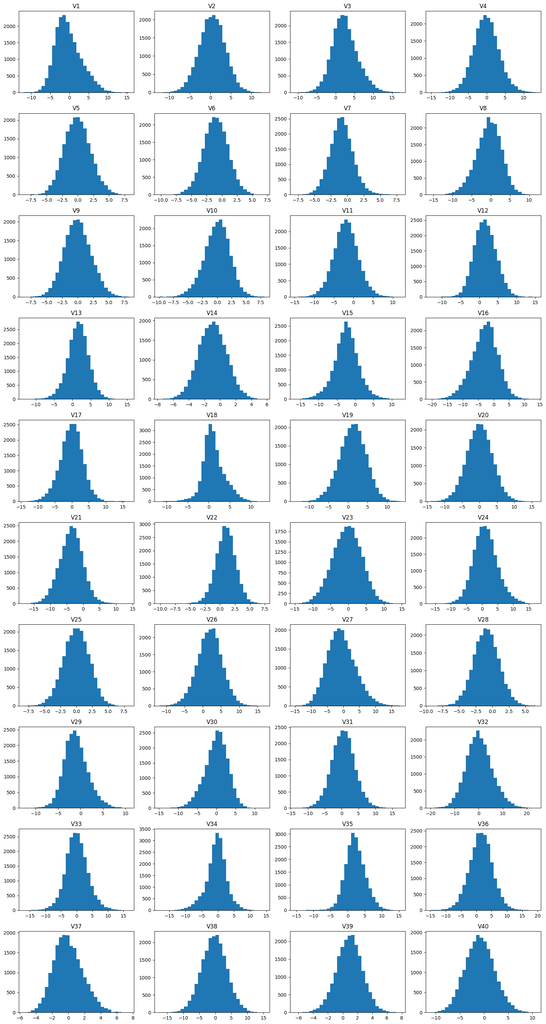

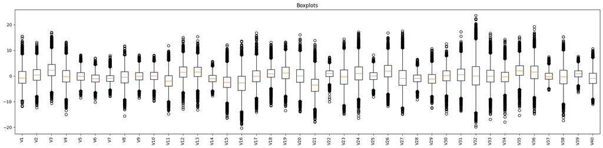

```
Target counts:
 Target
0    18890
1     1110
Name: count, dtype: int64
```

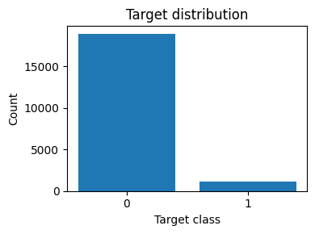

```python
target_col = "Target"

df = pd.DataFrame(X, columns=[f"V{i}" for i in range(1, X.shape[1] + 1)])
df[target_col] = y

# Statistics for numerical features
numeric_cols = df.select_dtypes(include=[np.number]).columns.tolist()
numeric_cols.remove(target_col)

desc = df[numeric_cols].describe().T
print(desc)

# Missing values
na_table = (
    df.isna().sum()
      .loc[lambda s: s > 0]
      .sort_values(ascending=False)
      .to_frame("missing_count")
)
print(na_table)

# Histograms
n = len(numeric_cols)
cols = 4
rows = int(np.ceil(n / cols))
plt.figure(figsize=(4*cols, 3*rows))
for i, col in enumerate(numeric_cols, 1):
    ax = plt.subplot(rows, cols, i)
    ax.hist(df[col].dropna(), bins=30)
    ax.set_title(col)
plt.tight_layout()
plt.show()

# Boxplots
plt.figure(figsize=(max(8, 0.5*len(numeric_cols)), 5))
plt.boxplot([df[c].dropna().values for c in numeric_cols],
            vert=True, labels=numeric_cols)
plt.xticks(rotation=90)
plt.title("Boxplots")
plt.tight_layout()
plt.show()

# Target distribution
counts = df[target_col].value_counts(dropna=False).sort_index()
print("Target counts:\n", counts)
plt.figure(figsize=(4,3))
plt.bar(counts.index.astype(str), counts.values)
plt.title("Target distribution")
plt.xlabel("Target class")
plt.ylabel("Count")
plt.tight_layout()
plt.show()
```

The dataset shows three main patterns: feature distributions, correlations with the target, and class balance.

**Feature Distribution:** Most features are roughly normally distributed with some outliers. Features V1 and V2 each have 18 missing values that need to be addressed.

**Target Balance:** The target is highly imbalanced, with far more “0” cases than “1,” a key factor to consider when training predictive models.

## Bivariate Analysis

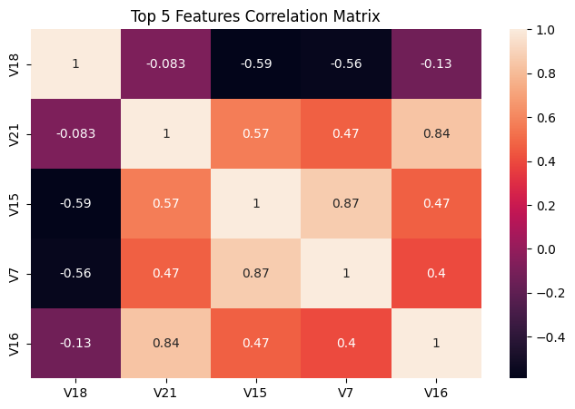

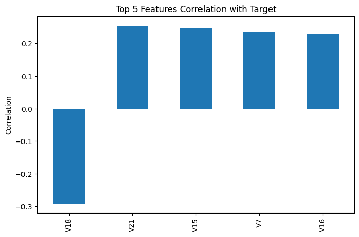

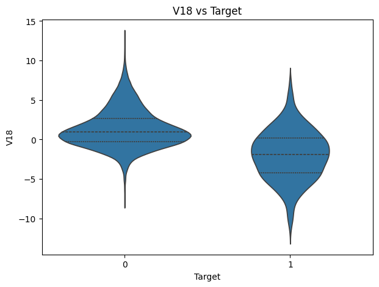

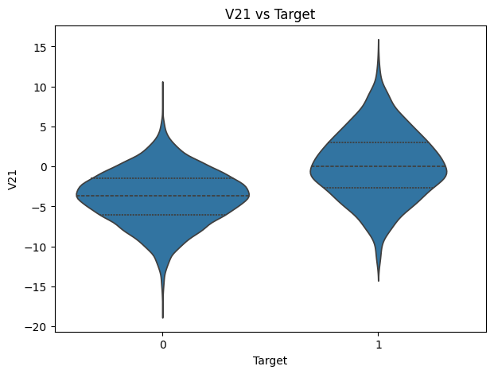

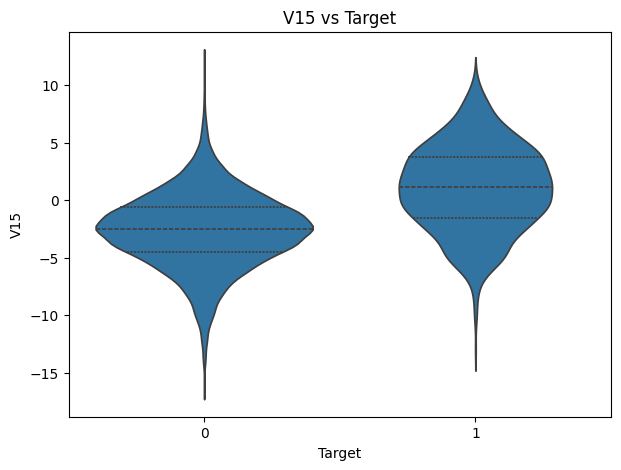

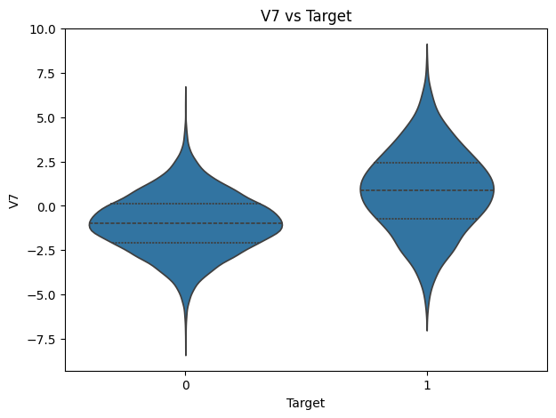

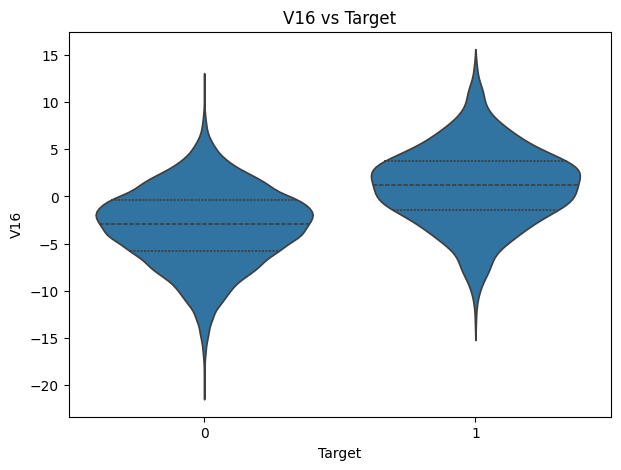

```python
# Correlations
feature_target_corr = train_df.corr()[target_col].drop(target_col)

# Ttop 5 features most correlated
top_features = feature_target_corr.abs().sort_values(ascending=False).head(5).index

# Heatmap
plt.figure(figsize=(8, 5))
sns.heatmap(train_df[top_features].corr(), annot=True)
plt.title("Top 5 Features Correlation Matrix")
plt.show()

# Bar plot
plt.figure(figsize=(8, 5))
feature_target_corr[top_features].plot(kind='bar')
plt.title("Top 5 Features Correlation with Target")
plt.ylabel("Correlation")
plt.show()

# Distribution
top5_features = feature_target_corr.abs().sort_values(ascending=False).head(5).index

for col in top5_features:
    plt.figure(figsize=(7, 5))
    sns.violinplot(x=target_col, y=col, data=train_df, inner="quartile")
    plt.title(f"{col} vs {target_col}")
    plt.show()
```

Violin plots were used to compare feature distributions across the two target classes (0 and 1).

These patterns visually confirm the correlations identified earlier and illustrate how feature values differ between classes.

# **Data Preprocessing**

```python
# Missing values treatment
for col in train_df.columns:
    if train_df[col].dtype == "object":
        mode_val = train_df[col].mode()[0]
        train_df[col] = train_df[col].fillna(mode_val)
        test_df[col] = test_df[col].fillna(mode_val)
    else:
        median_val = train_df[col].median()
        train_df[col] = train_df[col].fillna(median_val)
        test_df[col] = test_df[col].fillna(median_val)

# Encode categorical vars
cat_cols = [c for c in train_df.columns if train_df[c].dtype == "object"]
le = LabelEncoder()
for col in cat_cols:
    train_df[col] = le.fit_transform(train_df[col])
    test_df[col] = le.transform(test_df[col])

X = train_df.drop(columns=[target_col])
y = train_df[target_col]
X_test = test_df.drop(columns=[target_col], errors="ignore")
y_test = test_df[target_col] if target_col in test_df else None

X_train, X_valid, y_train, y_valid = train_test_split(
    X, y, test_size=0.2, random_state=42, stratify=y
)

# Treat class imbalance
smote = SMOTE(random_state=42)
X_train_res, y_train_res = smote.fit_resample(X_train, y_train)

# Feature scaling
scaler = StandardScaler()
X_train_scaled = scaler.fit_transform(X_train_res)
X_valid_scaled = scaler.transform(X_valid)
X_test_scaled = scaler.transform(X_test)
```

# Model Evaluation Criterion

To measure how well our predictive maintenance models perform, we focus on the following metrics:

TP (True Positive): Correctly detected failure → repair (moderate cost)

FP (False Positive): False alarm → inspection (low cost)

FN (False Negative): Missed failure → breakdown (very high cost)

Because missed failures are far more expensive, recall for the failure class is the key metric. Accuracy is a secondary measure.

Accuracy: Overall percentage of correct predictions.

Because the cost of a missed failure is far higher than the cost of a false alarm, reducing false negatives (FN) is the top priority, followed by managing false positives.

## Initial Model Building (Model 0)

- Let's start with a neural network consisting of
  - just one hidden layer
  - activation function of ReLU
  - SGD as the optimizer

```python
input_dim = X_train.shape[1]

model_0 = Sequential([
    Dense(16, activation='relu', input_shape=(input_dim,)),
    Dense(1, activation='sigmoid')
])

model_0.compile(
    optimizer=SGD(learning_rate=0.01),
    loss='binary_crossentropy',
    metrics=['accuracy']
)

# Train
history_0 = model_0.fit(
    X_train, y_train,
    validation_data=(X_valid, y_valid),
    epochs=20,
    batch_size=32,
    verbose=1
)

val_loss, val_acc = model_0.evaluate(X_valid, y_valid, verbose=0)
print(f"Model 0 Accuracy: {val_acc:.4f}")

y_pred_prob = model_0.predict(X_valid)
y_pred = (y_pred_prob > 0.5).astype(int)

val_recall = recall_score(y_valid, y_pred, pos_label=1)
print(f"Model 0 Recall: {val_recall:.4f}")
```

```
500/500 ━━━━━━━━━━━━━━━━━━━━ 1s 2ms/step - accuracy: 0.9036 - loss: 0.3152 - val_accuracy: 0.9725 - val_loss: 0.1075
500/500 ━━━━━━━━━━━━━━━━━━━━ 1s 2ms/step - accuracy: 0.9735 - loss: 0.1016 - val_accuracy: 0.9790 - val_loss: 0.0893
500/500 ━━━━━━━━━━━━━━━━━━━━ 1s 2ms/step - accuracy: 0.9811 - loss: 0.0793 - val_accuracy: 0.9822 - val_loss: 0.0803
500/500 ━━━━━━━━━━━━━━━━━━━━ 1s 2ms/step - accuracy: 0.9853 - loss: 0.0672 - val_accuracy: 0.9858 - val_loss: 0.0766
500/500 ━━━━━━━━━━━━━━━━━━━━ 1s 2ms/step - accuracy: 0.9846 - loss: 0.0723 - val_accuracy: 0.9858 - val_loss: 0.0727
500/500 ━━━━━━━━━━━━━━━━━━━━ 2s 3ms/step - accuracy: 0.9855 - loss: 0.0689 - val_accuracy: 0.9870 - val_loss: 0.0704
500/500 ━━━━━━━━━━━━━━━━━━━━ 3s 3ms/step - accuracy: 0.9858 - loss: 0.0674 - val_accuracy: 0.9870 - val_loss: 0.0686
500/500 ━━━━━━━━━━━━━━━━━━━━ 2s 2ms/step - accuracy: 0.9865 - loss: 0.0630 - val_accuracy: 0.9872 - val_loss: 0.0673
500/500 ━━━━━━━━━━━━━━━━━━━━ 1s 2ms/step - accuracy: 0.9866 - loss: 0.0625 - val_accuracy: 0.9880 - val_loss: 0.0661
500/500 ━━━━━━━━━━━━━━━━━━━━ 1s 2ms/step - accuracy: 0.9873 - loss: 0.0620 - val_accuracy: 0.9875 - val_loss: 0.0655
500/500 ━━━━━━━━━━━━━━━━━━━━ 1s 2ms/step - accuracy: 0.9868 - loss: 0.0632 - val_accuracy: 0.9877 - val_loss: 0.0643
500/500 ━━━━━━━━━━━━━━━━━━━━ 1s 2ms/step - accuracy: 0.9883 - loss: 0.0539 - val_accuracy: 0.9883 - val_loss: 0.0641
500/500 ━━━━━━━━━━━━━━━━━━━━ 1s 2ms/step - accuracy: 0.9864 - loss: 0.0640 - val_accuracy: 0.9887 - val_loss: 0.0629
500/500 ━━━━━━━━━━━━━━━━━━━━ 1s 2ms/step - accuracy: 0.9876 - loss: 0.0560 - val_accuracy: 0.9890 - val_loss: 0.0623
500/500 ━━━━━━━━━━━━━━━━━━━━ 2s 3ms/step - accuracy: 0.9875 - loss: 0.0609 - val_accuracy: 0.9883 - val_loss: 0.0621
500/500 ━━━━━━━━━━━━━━━━━━━━ 2s 2ms/step - accuracy: 0.9892 - loss: 0.0535 - val_accuracy: 0.9890 - val_loss: 0.0617
500/500 ━━━━━━━━━━━━━━━━━━━━ 1s 2ms/step - accuracy: 0.9883 - loss: 0.0554 - val_accuracy: 0.9893 - val_loss: 0.0612
500/500 ━━━━━━━━━━━━━━━━━━━━ 1s 2ms/step - accuracy: 0.9871 - loss: 0.0597 - val_accuracy: 0.9893 - val_loss: 0.0612
500/500 ━━━━━━━━━━━━━━━━━━━━ 1s 2ms/step - accuracy: 0.9884 - loss: 0.0575 - val_accuracy: 0.9887 - val_loss: 0.0607
500/500 ━━━━━━━━━━━━━━━━━━━━ 1s 2ms/step - accuracy: 0.9890 - loss: 0.0560 - val_accuracy: 0.9890 - val_loss: 0.0612
Model 0 Accuracy: 0.9890
125/125 ━━━━━━━━━━━━━━━━━━━━ 0s 1ms/step
Model 0 Recall: 0.8288
```

# **Model Performance Improvement**

## Model 1

More Hidden Layers

Approach: Introduce a second hidden layer.

Rationale: Adding depth enables the model to learn and represent more complex patterns in the data.

```python
model_1 = Sequential([
    Dense(32, activation='relu', input_shape=(input_dim,)),
    Dense(16, activation='relu'),
    Dense(1, activation='sigmoid')
])

model_1.compile(
    optimizer=SGD(learning_rate=0.01),
    loss='binary_crossentropy',
    metrics=[Recall(name="recall")]
)

history_1 = model_1.fit(
    X_train, y_train,
    validation_data=(X_valid, y_valid),
    epochs=20,
    batch_size=32,
    verbose=1
)
```

```
500/500 ━━━━━━━━━━━━━━━━━━━━ 2s 3ms/step - loss: 0.2319 - recall: 0.3419 - val_loss: 0.1190 - val_recall: 0.4550
500/500 ━━━━━━━━━━━━━━━━━━━━ 2s 2ms/step - loss: 0.1093 - recall: 0.5292 - val_loss: 0.0949 - val_recall: 0.6081
500/500 ━━━━━━━━━━━━━━━━━━━━ 3s 3ms/step - loss: 0.0855 - recall: 0.6390 - val_loss: 0.0815 - val_recall: 0.7117
500/500 ━━━━━━━━━━━━━━━━━━━━ 2s 2ms/step - loss: 0.0854 - recall: 0.6953 - val_loss: 0.0737 - val_recall: 0.7207
500/500 ━━━━━━━━━━━━━━━━━━━━ 1s 2ms/step - loss: 0.0727 - recall: 0.7343 - val_loss: 0.0684 - val_recall: 0.7432
500/500 ━━━━━━━━━━━━━━━━━━━━ 1s 2ms/step - loss: 0.0713 - recall: 0.7679 - val_loss: 0.0645 - val_recall: 0.7658
500/500 ━━━━━━━━━━━━━━━━━━━━ 1s 2ms/step - loss: 0.0599 - recall: 0.8034 - val_loss: 0.0611 - val_recall: 0.7838
500/500 ━━━━━━━━━━━━━━━━━━━━ 1s 2ms/step - loss: 0.0614 - recall: 0.8052 - val_loss: 0.0593 - val_recall: 0.8018
500/500 ━━━━━━━━━━━━━━━━━━━━ 1s 2ms/step - loss: 0.0573 - recall: 0.8055 - val_loss: 0.0579 - val_recall: 0.8198
500/500 ━━━━━━━━━━━━━━━━━━━━ 1s 2ms/step - loss: 0.0591 - recall: 0.7898 - val_loss: 0.0567 - val_recall: 0.8198
500/500 ━━━━━━━━━━━━━━━━━━━━ 2s 3ms/step - loss: 0.0587 - recall: 0.8052 - val_loss: 0.0559 - val_recall: 0.8378
500/500 ━━━━━━━━━━━━━━━━━━━━ 2s 3ms/step - loss: 0.0583 - recall: 0.8120 - val_loss: 0.0554 - val_recall: 0.8243
500/500 ━━━━━━━━━━━━━━━━━━━━ 2s 2ms/step - loss: 0.0512 - recall: 0.8275 - val_loss: 0.0545 - val_recall: 0.8378
500/500 ━━━━━━━━━━━━━━━━━━━━ 1s 2ms/step - loss: 0.0518 - recall: 0.8264 - val_loss: 0.0534 - val_recall: 0.8423
500/500 ━━━━━━━━━━━━━━━━━━━━ 1s 2ms/step - loss: 0.0501 - recall: 0.8352 - val_loss: 0.0537 - val_recall: 0.8604
500/500 ━━━━━━━━━━━━━━━━━━━━ 1s 2ms/step - loss: 0.0483 - recall: 0.8372 - val_loss: 0.0529 - val_recall: 0.8198
500/500 ━━━━━━━━━━━━━━━━━━━━ 1s 2ms/step - loss: 0.0565 - recall: 0.8191 - val_loss: 0.0523 - val_recall: 0.8559
500/500 ━━━━━━━━━━━━━━━━━━━━ 1s 2ms/step - loss: 0.0501 - recall: 0.8082 - val_loss: 0.0521 - val_recall: 0.8694
500/500 ━━━━━━━━━━━━━━━━━━━━ 1s 2ms/step - loss: 0.0498 - recall: 0.8511 - val_loss: 0.0510 - val_recall: 0.8514
500/500 ━━━━━━━━━━━━━━━━━━━━ 2s 3ms/step - loss: 0.0476 - recall: 0.8466 - val_loss: 0.0512 - val_recall: 0.8604
```

## Model 2

Different Optimizer (Adam)

Approach: Replace SGD with the Adam optimizer.

Rationale: Adam adjusts learning rates automatically, often leading to faster and more effective convergence.

```python
model_2 = Sequential([
    Dense(32, activation='relu', input_shape=(input_dim,)),
    Dense(16, activation='relu'),
    Dense(1, activation='sigmoid')
])

model_2.compile(
    optimizer='adam',
    loss='binary_crossentropy',
    metrics=['accuracy', Recall(name="recall")]
)

history_2 = model_2.fit(
    X_train, y_train,
    validation_data=(X_valid, y_valid),
    epochs=20,
    batch_size=32,
    verbose=1
)
```

```
500/500 ━━━━━━━━━━━━━━━━━━━━ 3s 3ms/step - accuracy: 0.8150 - loss: 0.4849 - recall: 0.5440 - val_accuracy: 0.9822 - val_loss: 0.0781 - val_recall: 0.7162
500/500 ━━━━━━━━━━━━━━━━━━━━ 2s 2ms/step - accuracy: 0.9847 - loss: 0.0679 - recall: 0.7548 - val_accuracy: 0.9877 - val_loss: 0.0628 - val_recall: 0.8018
500/500 ━━━━━━━━━━━━━━━━━━━━ 1s 2ms/step - accuracy: 0.9870 - loss: 0.0623 - recall: 0.7941 - val_accuracy: 0.9893 - val_loss: 0.0562 - val_recall: 0.8468
500/500 ━━━━━━━━━━━━━━━━━━━━ 1s 2ms/step - accuracy: 0.9887 - loss: 0.0531 - recall: 0.8250 - val_accuracy: 0.9910 - val_loss: 0.0550 - val_recall: 0.8559
500/500 ━━━━━━━━━━━━━━━━━━━━ 1s 2ms/step - accuracy: 0.9888 - loss: 0.0537 - recall: 0.8260 - val_accuracy: 0.9900 - val_loss: 0.0543 - val_recall: 0.8739
500/500 ━━━━━━━━━━━━━━━━━━━━ 1s 2ms/step - accuracy: 0.9892 - loss: 0.0537 - recall: 0.8439 - val_accuracy: 0.9910 - val_loss: 0.0514 - val_recall: 0.8784
500/500 ━━━━━━━━━━━━━━━━━━━━ 2s 3ms/step - accuracy: 0.9902 - loss: 0.0470 - recall: 0.8382 - val_accuracy: 0.9908 - val_loss: 0.0513 - val_recall: 0.8784
500/500 ━━━━━━━━━━━━━━━━━━━━ 3s 3ms/step - accuracy: 0.9901 - loss: 0.0470 - recall: 0.8408 - val_accuracy: 0.9910 - val_loss: 0.0492 - val_recall: 0.8919
500/500 ━━━━━━━━━━━━━━━━━━━━ 2s 2ms/step - accuracy: 0.9917 - loss: 0.0436 - recall: 0.8702 - val_accuracy: 0.9908 - val_loss: 0.0517 - val_recall: 0.8919
500/500 ━━━━━━━━━━━━━━━━━━━━ 1s 2ms/step - accuracy: 0.9919 - loss: 0.0387 - recall: 0.8600 - val_accuracy: 0.9920 - val_loss: 0.0476 - val_recall: 0.8919
500/500 ━━━━━━━━━━━━━━━━━━━━ 1s 2ms/step - accuracy: 0.9925 - loss: 0.0400 - recall: 0.8726 - val_accuracy: 0.9905 - val_loss: 0.0492 - val_recall: 0.8919
500/500 ━━━━━━━━━━━━━━━━━━━━ 1s 3ms/step - accuracy: 0.9937 - loss: 0.0307 - recall: 0.9066 - val_accuracy: 0.9912 - val_loss: 0.0485 - val_recall: 0.8784
500/500 ━━━━━━━━━━━━━━━━━━━━ 1s 2ms/step - accuracy: 0.9927 - loss: 0.0363 - recall: 0.8827 - val_accuracy: 0.9910 - val_loss: 0.0522 - val_recall: 0.8604
500/500 ━━━━━━━━━━━━━━━━━━━━ 1s 2ms/step - accuracy: 0.9924 - loss: 0.0387 - recall: 0.8805 - val_accuracy: 0.9927 - val_loss: 0.0462 - val_recall: 0.8874
500/500 ━━━━━━━━━━━━━━━━━━━━ 1s 3ms/step - accuracy: 0.9926 - loss: 0.0364 - recall: 0.8842 - val_accuracy: 0.9925 - val_loss: 0.0458 - val_recall: 0.8919
500/500 ━━━━━━━━━━━━━━━━━━━━ 3s 3ms/step - accuracy: 0.9924 - loss: 0.0374 - recall: 0.8844 - val_accuracy: 0.9923 - val_loss: 0.0473 - val_recall: 0.9099
500/500 ━━━━━━━━━━━━━━━━━━━━ 2s 2ms/step - accuracy: 0.9910 - loss: 0.0402 - recall: 0.8611 - val_accuracy: 0.9915 - val_loss: 0.0524 - val_recall: 0.8964
500/500 ━━━━━━━━━━━━━━━━━━━━ 3s 2ms/step - accuracy: 0.9928 - loss: 0.0334 - recall: 0.8930 - val_accuracy: 0.9925 - val_loss: 0.0465 - val_recall: 0.8964
500/500 ━━━━━━━━━━━━━━━━━━━━ 1s 2ms/step - accuracy: 0.9928 - loss: 0.0362 - recall: 0.8921 - val_accuracy: 0.9935 - val_loss: 0.0461 - val_recall: 0.9009
500/500 ━━━━━━━━━━━━━━━━━━━━ 1s 2ms/step - accuracy: 0.9939 - loss: 0.0300 - recall: 0.9042 - val_accuracy: 0.9918 - val_loss: 0.0471 - val_recall: 0.9144
```

## Model 3

Dropout Regularization

Approach: Insert dropout layers after the hidden layers.

Rationale: Dropout helps reduce overfitting by randomly deactivating neurons during training, encouraging the network to generalize better.

```python
model_3 = Sequential([
    Dense(32, activation='relu', input_shape=(input_dim,)),
    Dropout(0.3),
    Dense(16, activation='relu'),
    Dropout(0.3),
    Dense(1, activation='sigmoid')
])

model_3.compile(
    optimizer='adam',
    loss='binary_crossentropy',
    metrics=['accuracy', Recall(name="recall")]
)

history_3 = model_3.fit(
    X_train, y_train,
    validation_data=(X_valid, y_valid),
    epochs=30,
    batch_size=32,
    verbose=1
)
```

```
500/500 ━━━━━━━━━━━━━━━━━━━━ 3s 3ms/step - accuracy: 0.9067 - loss: 0.2665 - recall: 0.3436 - val_accuracy: 0.9775 - val_loss: 0.0971 - val_recall: 0.6171
500/500 ━━━━━━━━━━━━━━━━━━━━ 3s 3ms/step - accuracy: 0.9680 - loss: 0.1265 - recall: 0.5029 - val_accuracy: 0.9827 - val_loss: 0.0795 - val_recall: 0.7027
500/500 ━━━━━━━━━━━━━━━━━━━━ 2s 2ms/step - accuracy: 0.9745 - loss: 0.1024 - recall: 0.5936 - val_accuracy: 0.9865 - val_loss: 0.0701 - val_recall: 0.7748
500/500 ━━━━━━━━━━━━━━━━━━━━ 1s 2ms/step - accuracy: 0.9780 - loss: 0.0981 - recall: 0.6686 - val_accuracy: 0.9860 - val_loss: 0.0645 - val_recall: 0.7748
500/500 ━━━━━━━━━━━━━━━━━━━━ 2s 2ms/step - accuracy: 0.9813 - loss: 0.0831 - recall: 0.7452 - val_accuracy: 0.9868 - val_loss: 0.0628 - val_recall: 0.7748
500/500 ━━━━━━━━━━━━━━━━━━━━ 1s 2ms/step - accuracy: 0.9813 - loss: 0.0832 - recall: 0.7149 - val_accuracy: 0.9877 - val_loss: 0.0563 - val_recall: 0.7973
500/500 ━━━━━━━━━━━━━━━━━━━━ 1s 2ms/step - accuracy: 0.9817 - loss: 0.0793 - recall: 0.7224 - val_accuracy: 0.9885 - val_loss: 0.0571 - val_recall: 0.8108
500/500 ━━━━━━━━━━━━━━━━━━━━ 1s 2ms/step - accuracy: 0.9850 - loss: 0.0732 - recall: 0.7758 - val_accuracy: 0.9893 - val_loss: 0.0551 - val_recall: 0.8333
500/500 ━━━━━━━━━━━━━━━━━━━━ 2s 3ms/step - accuracy: 0.9850 - loss: 0.0661 - recall: 0.7632 - val_accuracy: 0.9900 - val_loss: 0.0529 - val_recall: 0.8378
500/500 ━━━━━━━━━━━━━━━━━━━━ 3s 3ms/step - accuracy: 0.9862 - loss: 0.0709 - recall: 0.7989 - val_accuracy: 0.9898 - val_loss: 0.0520 - val_recall: 0.8288
500/500 ━━━━━━━━━━━━━━━━━━━━ 1s 2ms/step - accuracy: 0.9847 - loss: 0.0675 - recall: 0.7792 - val_accuracy: 0.9895 - val_loss: 0.0533 - val_recall: 0.8243
500/500 ━━━━━━━━━━━━━━━━━━━━ 1s 2ms/step - accuracy: 0.9840 - loss: 0.0658 - recall: 0.7578 - val_accuracy: 0.9900 - val_loss: 0.0504 - val_recall: 0.8333
500/500 ━━━━━━━━━━━━━━━━━━━━ 1s 2ms/step - accuracy: 0.9864 - loss: 0.0640 - recall: 0.7958 - val_accuracy: 0.9885 - val_loss: 0.0509 - val_recall: 0.8063
500/500 ━━━━━━━━━━━━━━━━━━━━ 1s 3ms/step - accuracy: 0.9861 - loss: 0.0641 - recall: 0.7857 - val_accuracy: 0.9902 - val_loss: 0.0500 - val_recall: 0.8333
500/500 ━━━━━━━━━━━━━━━━━━━━ 1s 3ms/step - accuracy: 0.9865 - loss: 0.0632 - recall: 0.7991 - val_accuracy: 0.9908 - val_loss: 0.0474 - val_recall: 0.8514
500/500 ━━━━━━━━━━━━━━━━━━━━ 3s 2ms/step - accuracy: 0.9880 - loss: 0.0543 - recall: 0.8193 - val_accuracy: 0.9887 - val_loss: 0.0505 - val_recall: 0.8198
500/500 ━━━━━━━━━━━━━━━━━━━━ 3s 3ms/step - accuracy: 0.9842 - loss: 0.0633 - recall: 0.7718 - val_accuracy: 0.9898 - val_loss: 0.0464 - val_recall: 0.8288
500/500 ━━━━━━━━━━━━━━━━━━━━ 2s 3ms/step - accuracy: 0.9869 - loss: 0.0577 - recall: 0.8015 - val_accuracy: 0.9902 - val_loss: 0.0463 - val_recall: 0.8423
500/500 ━━━━━━━━━━━━━━━━━━━━ 2s 3ms/step - accuracy: 0.9852 - loss: 0.0669 - recall: 0.7746 - val_accuracy: 0.9900 - val_loss: 0.0461 - val_recall: 0.8423
500/500 ━━━━━━━━━━━━━━━━━━━━ 2s 3ms/step - accuracy: 0.9868 - loss: 0.0615 - recall: 0.7981 - val_accuracy: 0.9912 - val_loss: 0.0449 - val_recall: 0.8649
500/500 ━━━━━━━━━━━━━━━━━━━━ 1s 2ms/step - accuracy: 0.9868 - loss: 0.0610 - recall: 0.7935 - val_accuracy: 0.9915 - val_loss: 0.0435 - val_recall: 0.8649
500/500 ━━━━━━━━━━━━━━━━━━━━ 1s 3ms/step - accuracy: 0.9861 - loss: 0.0606 - recall: 0.7851 - val_accuracy: 0.9908 - val_loss: 0.0451 - val_recall: 0.8468
500/500 ━━━━━━━━━━━━━━━━━━━━ 3s 3ms/step - accuracy: 0.9854 - loss: 0.0681 - recall: 0.7808 - val_accuracy: 0.9902 - val_loss: 0.0448 - val_recall: 0.8333
500/500 ━━━━━━━━━━━━━━━━━━━━ 2s 4ms/step - accuracy: 0.9880 - loss: 0.0557 - recall: 0.8124 - val_accuracy: 0.9915 - val_loss: 0.0437 - val_recall: 0.8694
500/500 ━━━━━━━━━━━━━━━━━━━━ 1s 3ms/step - accuracy: 0.9862 - loss: 0.0607 - recall: 0.7866 - val_accuracy: 0.9910 - val_loss: 0.0439 - val_recall: 0.8423
500/500 ━━━━━━━━━━━━━━━━━━━━ 1s 3ms/step - accuracy: 0.9876 - loss: 0.0556 - recall: 0.8035 - val_accuracy: 0.9925 - val_loss: 0.0418 - val_recall: 0.8784
500/500 ━━━━━━━━━━━━━━━━━━━━ 1s 2ms/step - accuracy: 0.9890 - loss: 0.0484 - recall: 0.8143 - val_accuracy: 0.9933 - val_loss: 0.0411 - val_recall: 0.8829
500/500 ━━━━━━━━━━━━━━━━━━━━ 3s 3ms/step - accuracy: 0.9859 - loss: 0.0585 - recall: 0.7838 - val_accuracy: 0.9915 - val_loss: 0.0429 - val_recall: 0.8604
500/500 ━━━━━━━━━━━━━━━━━━━━ 2s 2ms/step - accuracy: 0.9867 - loss: 0.0595 - recall: 0.7907 - val_accuracy: 0.9930 - val_loss: 0.0409 - val_recall: 0.8874
500/500 ━━━━━━━━━━━━━━━━━━━━ 1s 3ms/step - accuracy: 0.9894 - loss: 0.0458 - recall: 0.8271 - val_accuracy: 0.9935 - val_loss: 0.0410 - val_recall: 0.9009
```

## Model 4

Adam and more hidden Layers

Approach: Use three hidden layers with the Adam optimizer.

Rationale: Increasing network depth alongside a powerful optimizer enhances the model’s ability to capture and learn complex patterns.

```python
model_4 = Sequential([
    Dense(32, activation='relu', input_shape=(input_dim,)),
    Dense(16, activation='relu'),
    Dense(8, activation='relu'),
    Dense(1, activation='sigmoid')
])

model_4.compile(
    optimizer='adam',
    loss='binary_crossentropy',
    metrics=['accuracy', Recall(name="recall")]
)

history_4 = model_4.fit(
    X_train, y_train,
    validation_data=(X_valid, y_valid),
    epochs=30,
    batch_size=32,
    verbose=1
)
```

```
500/500 ━━━━━━━━━━━━━━━━━━━━ 3s 3ms/step - accuracy: 0.9547 - loss: 0.1513 - recall: 0.3601 - val_accuracy: 0.9870 - val_loss: 0.0662 - val_recall: 0.8063
500/500 ━━━━━━━━━━━━━━━━━━━━ 2s 3ms/step - accuracy: 0.9878 - loss: 0.0623 - recall: 0.8058 - val_accuracy: 0.9900 - val_loss: 0.0576 - val_recall: 0.8468
500/500 ━━━━━━━━━━━━━━━━━━━━ 3s 3ms/step - accuracy: 0.9891 - loss: 0.0525 - recall: 0.8288 - val_accuracy: 0.9910 - val_loss: 0.0502 - val_recall: 0.8739
500/500 ━━━━━━━━━━━━━━━━━━━━ 2s 2ms/step - accuracy: 0.9917 - loss: 0.0446 - recall: 0.8645 - val_accuracy: 0.9905 - val_loss: 0.0488 - val_recall: 0.8784
500/500 ━━━━━━━━━━━━━━━━━━━━ 1s 3ms/step - accuracy: 0.9894 - loss: 0.0481 - recall: 0.8370 - val_accuracy: 0.9923 - val_loss: 0.0439 - val_recall: 0.8919
500/500 ━━━━━━━━━━━━━━━━━━━━ 3s 3ms/step - accuracy: 0.9904 - loss: 0.0467 - recall: 0.8549 - val_accuracy: 0.9915 - val_loss: 0.0452 - val_recall: 0.8784
500/500 ━━━━━━━━━━━━━━━━━━━━ 2s 2ms/step - accuracy: 0.9913 - loss: 0.0430 - recall: 0.8632 - val_accuracy: 0.9918 - val_loss: 0.0456 - val_recall: 0.9144
500/500 ━━━━━━━━━━━━━━━━━━━━ 1s 2ms/step - accuracy: 0.9923 - loss: 0.0389 - recall: 0.8680 - val_accuracy: 0.9900 - val_loss: 0.0482 - val_recall: 0.8874
500/500 ━━━━━━━━━━━━━━━━━━━━ 3s 3ms/step - accuracy: 0.9925 - loss: 0.0367 - recall: 0.8844 - val_accuracy: 0.9918 - val_loss: 0.0420 - val_recall: 0.8829
500/500 ━━━━━━━━━━━━━━━━━━━━ 2s 2ms/step - accuracy: 0.9930 - loss: 0.0381 - recall: 0.8868 - val_accuracy: 0.9923 - val_loss: 0.0441 - val_recall: 0.8739
500/500 ━━━━━━━━━━━━━━━━━━━━ 1s 2ms/step - accuracy: 0.9922 - loss: 0.0407 - recall: 0.8794 - val_accuracy: 0.9918 - val_loss: 0.0456 - val_recall: 0.9099
500/500 ━━━━━━━━━━━━━━━━━━━━ 2s 3ms/step - accuracy: 0.9933 - loss: 0.0334 - recall: 0.8904 - val_accuracy: 0.9923 - val_loss: 0.0435 - val_recall: 0.9009
500/500 ━━━━━━━━━━━━━━━━━━━━ 2s 2ms/step - accuracy: 0.9937 - loss: 0.0317 - recall: 0.8970 - val_accuracy: 0.9920 - val_loss: 0.0397 - val_recall: 0.8874
500/500 ━━━━━━━━━━━━━━━━━━━━ 1s 2ms/step - accuracy: 0.9936 - loss: 0.0314 - recall: 0.8960 - val_accuracy: 0.9925 - val_loss: 0.0431 - val_recall: 0.9009
500/500 ━━━━━━━━━━━━━━━━━━━━ 1s 2ms/step - accuracy: 0.9926 - loss: 0.0375 - recall: 0.8796 - val_accuracy: 0.9930 - val_loss: 0.0409 - val_recall: 0.8964
500/500 ━━━━━━━━━━━━━━━━━━━━ 1s 2ms/step - accuracy: 0.9938 - loss: 0.0327 - recall: 0.8899 - val_accuracy: 0.9912 - val_loss: 0.0478 - val_recall: 0.9054
500/500 ━━━━━━━━━━━━━━━━━━━━ 1s 2ms/step - accuracy: 0.9933 - loss: 0.0320 - recall: 0.8901 - val_accuracy: 0.9908 - val_loss: 0.0443 - val_recall: 0.8604
500/500 ━━━━━━━━━━━━━━━━━━━━ 1s 2ms/step - accuracy: 0.9938 - loss: 0.0333 - recall: 0.8947 - val_accuracy: 0.9920 - val_loss: 0.0437 - val_recall: 0.8964
500/500 ━━━━━━━━━━━━━━━━━━━━ 3s 2ms/step - accuracy: 0.9928 - loss: 0.0346 - recall: 0.8795 - val_accuracy: 0.9920 - val_loss: 0.0425 - val_recall: 0.8784
500/500 ━━━━━━━━━━━━━━━━━━━━ 2s 3ms/step - accuracy: 0.9943 - loss: 0.0306 - recall: 0.9093 - val_accuracy: 0.9912 - val_loss: 0.0460 - val_recall: 0.9009
500/500 ━━━━━━━━━━━━━━━━━━━━ 3s 3ms/step - accuracy: 0.9942 - loss: 0.0293 - recall: 0.8965 - val_accuracy: 0.9920 - val_loss: 0.0422 - val_recall: 0.9009
500/500 ━━━━━━━━━━━━━━━━━━━━ 2s 2ms/step - accuracy: 0.9935 - loss: 0.0319 - recall: 0.8974 - val_accuracy: 0.9912 - val_loss: 0.0471 - val_recall: 0.8739
500/500 ━━━━━━━━━━━━━━━━━━━━ 3s 3ms/step - accuracy: 0.9942 - loss: 0.0241 - recall: 0.9084 - val_accuracy: 0.9910 - val_loss: 0.0474 - val_recall: 0.8874
500/500 ━━━━━━━━━━━━━━━━━━━━ 1s 2ms/step - accuracy: 0.9938 - loss: 0.0282 - recall: 0.8968 - val_accuracy: 0.9908 - val_loss: 0.0448 - val_recall: 0.8964
500/500 ━━━━━━━━━━━━━━━━━━━━ 1s 2ms/step - accuracy: 0.9931 - loss: 0.0304 - recall: 0.8923 - val_accuracy: 0.9923 - val_loss: 0.0437 - val_recall: 0.8964
500/500 ━━━━━━━━━━━━━━━━━━━━ 1s 3ms/step - accuracy: 0.9945 - loss: 0.0255 - recall: 0.9108 - val_accuracy: 0.9910 - val_loss: 0.0467 - val_recall: 0.9009
500/500 ━━━━━━━━━━━━━━━━━━━━ 3s 4ms/step - accuracy: 0.9932 - loss: 0.0292 - recall: 0.8829 - val_accuracy: 0.9923 - val_loss: 0.0465 - val_recall: 0.8964
500/500 ━━━━━━━━━━━━━━━━━━━━ 2s 2ms/step - accuracy: 0.9934 - loss: 0.0306 - recall: 0.8948 - val_accuracy: 0.9905 - val_loss: 0.0498 - val_recall: 0.8919
500/500 ━━━━━━━━━━━━━━━━━━━━ 1s 2ms/step - accuracy: 0.9935 - loss: 0.0273 - recall: 0.9021 - val_accuracy: 0.9927 - val_loss: 0.0475 - val_recall: 0.9054
500/500 ━━━━━━━━━━━━━━━━━━━━ 3s 3ms/step - accuracy: 0.9938 - loss: 0.0261 - recall: 0.9057 - val_accuracy: 0.9920 - val_loss: 0.0477 - val_recall: 0.9054
```

## Model 5

Class Weights

Approach: Apply class weights during training.

Rationale: In imbalanced datasets, weighting the loss function makes the model give more importance to the minority class, improving its ability to detect underrepresented outcomes.

```python
class_weights = compute_class_weight(
    class_weight='balanced',
    classes=np.unique(y_train),
    y=y_train
)
class_weight_dict = dict(enumerate(class_weights))

model_5 = Sequential([
    Dense(32, activation='relu', input_shape=(input_dim,)),
    Dense(16, activation='relu'),
    Dense(1, activation='sigmoid')
])

model_5.compile(
    optimizer='adam',
    loss='binary_crossentropy',
    metrics=['accuracy', Recall(name="recall")]
)

history_5 = model_5.fit(
    X_train, y_train,
    validation_data=(X_valid, y_valid),
    epochs=30,
    batch_size=32,
    class_weight=class_weight_dict,
    verbose=1
)
```

```
500/500 ━━━━━━━━━━━━━━━━━━━━ 2s 3ms/step - accuracy: 0.8047 - loss: 0.5483 - recall: 0.6981 - val_accuracy: 0.9525 - val_loss: 0.1980 - val_recall: 0.8964
500/500 ━━━━━━━━━━━━━━━━━━━━ 1s 2ms/step - accuracy: 0.9450 - loss: 0.2529 - recall: 0.8872 - val_accuracy: 0.9647 - val_loss: 0.1843 - val_recall: 0.9144
500/500 ━━━━━━━━━━━━━━━━━━━━ 1s 2ms/step - accuracy: 0.9697 - loss: 0.1959 - recall: 0.9114 - val_accuracy: 0.9780 - val_loss: 0.1544 - val_recall: 0.9144
500/500 ━━━━━━━━━━━━━━━━━━━━ 2s 3ms/step - accuracy: 0.9686 - loss: 0.1974 - recall: 0.8997 - val_accuracy: 0.9675 - val_loss: 0.1851 - val_recall: 0.9144
500/500 ━━━━━━━━━━━━━━━━━━━━ 2s 2ms/step - accuracy: 0.9747 - loss: 0.1880 - recall: 0.9089 - val_accuracy: 0.9680 - val_loss: 0.1513 - val_recall: 0.9144
500/500 ━━━━━━━━━━━━━━━━━━━━ 1s 2ms/step - accuracy: 0.9752 - loss: 0.1720 - recall: 0.9205 - val_accuracy: 0.9735 - val_loss: 0.1447 - val_recall: 0.9099
500/500 ━━━━━━━━━━━━━━━━━━━━ 2s 2ms/step - accuracy: 0.9758 - loss: 0.1648 - recall: 0.9200 - val_accuracy: 0.9743 - val_loss: 0.1492 - val_recall: 0.9144
500/500 ━━━━━━━━━━━━━━━━━━━━ 1s 2ms/step - accuracy: 0.9764 - loss: 0.1643 - recall: 0.9175 - val_accuracy: 0.9865 - val_loss: 0.1017 - val_recall: 0.9099
500/500 ━━━━━━━━━━━━━━━━━━━━ 1s 2ms/step - accuracy: 0.9814 - loss: 0.1368 - recall: 0.9300 - val_accuracy: 0.9770 - val_loss: 0.1367 - val_recall: 0.9054
500/500 ━━━━━━━━━━━━━━━━━━━━ 1s 2ms/step - accuracy: 0.9766 - loss: 0.1699 - recall: 0.9030 - val_accuracy: 0.9830 - val_loss: 0.1171 - val_recall: 0.9054
500/500 ━━━━━━━━━━━━━━━━━━━━ 1s 2ms/step - accuracy: 0.9824 - loss: 0.1374 - recall: 0.9283 - val_accuracy: 0.9795 - val_loss: 0.1349 - val_recall: 0.9144
500/500 ━━━━━━━━━━━━━━━━━━━━ 1s 3ms/step - accuracy: 0.9797 - loss: 0.1521 - recall: 0.9144 - val_accuracy: 0.9820 - val_loss: 0.1166 - val_recall: 0.9099
500/500 ━━━━━━━━━━━━━━━━━━━━ 3s 3ms/step - accuracy: 0.9794 - loss: 0.1510 - recall: 0.9159 - val_accuracy: 0.9665 - val_loss: 0.1660 - val_recall: 0.9099
500/500 ━━━━━━━━━━━━━━━━━━━━ 2s 2ms/step - accuracy: 0.9791 - loss: 0.1568 - recall: 0.9135 - val_accuracy: 0.9695 - val_loss: 0.1492 - val_recall: 0.9099
500/500 ━━━━━━━━━━━━━━━━━━━━ 1s 3ms/step - accuracy: 0.9828 - loss: 0.1339 - recall: 0.9216 - val_accuracy: 0.9793 - val_loss: 0.1128 - val_recall: 0.9009
500/500 ━━━━━━━━━━━━━━━━━━━━ 3s 2ms/step - accuracy: 0.9776 - loss: 0.1452 - recall: 0.9133 - val_accuracy: 0.9787 - val_loss: 0.1247 - val_recall: 0.9099
500/500 ━━━━━━━━━━━━━━━━━━━━ 1s 2ms/step - accuracy: 0.9813 - loss: 0.1207 - recall: 0.9321 - val_accuracy: 0.9797 - val_loss: 0.1163 - val_recall: 0.9099
500/500 ━━━━━━━━━━━━━━━━━━━━ 1s 2ms/step - accuracy: 0.9797 - loss: 0.1125 - recall: 0.9302 - val_accuracy: 0.9710 - val_loss: 0.1355 - val_recall: 0.9099
500/500 ━━━━━━━━━━━━━━━━━━━━ 1s 2ms/step - accuracy: 0.9818 - loss: 0.1227 - recall: 0.9122 - val_accuracy: 0.9762 - val_loss: 0.1164 - val_recall: 0.9054
500/500 ━━━━━━━━━━━━━━━━━━━━ 2s 3ms/step - accuracy: 0.9774 - loss: 0.1515 - recall: 0.9103 - val_accuracy: 0.9760 - val_loss: 0.1121 - val_recall: 0.9054
500/500 ━━━━━━━━━━━━━━━━━━━━ 2s 3ms/step - accuracy: 0.9830 - loss: 0.1219 - recall: 0.9276 - val_accuracy: 0.9797 - val_loss: 0.1115 - val_recall: 0.9144
500/500 ━━━━━━━━━━━━━━━━━━━━ 3s 2ms/step - accuracy: 0.9812 - loss: 0.1245 - recall: 0.9110 - val_accuracy: 0.9790 - val_loss: 0.1160 - val_recall: 0.9054
500/500 ━━━━━━━━━━━━━━━━━━━━ 1s 2ms/step - accuracy: 0.9830 - loss: 0.1107 - recall: 0.9371 - val_accuracy: 0.9833 - val_loss: 0.1044 - val_recall: 0.9099
500/500 ━━━━━━━━━━━━━━━━━━━━ 1s 2ms/step - accuracy: 0.9795 - loss: 0.1137 - recall: 0.9335 - val_accuracy: 0.9847 - val_loss: 0.1010 - val_recall: 0.9099
500/500 ━━━━━━━━━━━━━━━━━━━━ 1s 2ms/step - accuracy: 0.9843 - loss: 0.1128 - recall: 0.9409 - val_accuracy: 0.9675 - val_loss: 0.1360 - val_recall: 0.9099
500/500 ━━━━━━━━━━━━━━━━━━━━ 1s 2ms/step - accuracy: 0.9792 - loss: 0.1221 - recall: 0.9165 - val_accuracy: 0.9847 - val_loss: 0.0912 - val_recall: 0.9054
500/500 ━━━━━━━━━━━━━━━━━━━━ 1s 2ms/step - accuracy: 0.9835 - loss: 0.1053 - recall: 0.9368 - val_accuracy: 0.9815 - val_loss: 0.1114 - val_recall: 0.9054
500/500 ━━━━━━━━━━━━━━━━━━━━ 2s 3ms/step - accuracy: 0.9839 - loss: 0.0979 - recall: 0.9358 - val_accuracy: 0.9787 - val_loss: 0.1103 - val_recall: 0.9099
500/500 ━━━━━━━━━━━━━━━━━━━━ 2s 3ms/step - accuracy: 0.9816 - loss: 0.0971 - recall: 0.9430 - val_accuracy: 0.9815 - val_loss: 0.1004 - val_recall: 0.9054
500/500 ━━━━━━━━━━━━━━━━━━━━ 2s 2ms/step - accuracy: 0.9851 - loss: 0.0919 - recall: 0.9384 - val_accuracy: 0.9805 - val_loss: 0.1137 - val_recall: 0.9144
```

## Model 6

Dropout + Class Weights + Adam

Approach: Build a three-layer network using the Adam optimizer, add dropout for regularization, and apply class weights during training.

Rationale: This combination addresses both overfitting and class imbalance, improving the model’s robustness and sensitivity to minority class failures.

```python
model_6 = Sequential([
    Dense(32, activation='relu', input_shape=(input_dim,)),
    Dropout(0.3),
    Dense(16, activation='relu'),
    Dropout(0.3),
    Dense(8, activation='relu'),
    Dense(1, activation='sigmoid')
])

model_6.compile(
    optimizer='adam',
    loss='binary_crossentropy',
    metrics=['accuracy', Recall(name="recall")]
)

history_6 = model_6.fit(
    X_train, y_train,
    validation_data=(X_valid, y_valid),
    epochs=30,
    batch_size=32,
    class_weight=class_weight_dict,
    verbose=1
)
```

```
500/500 ━━━━━━━━━━━━━━━━━━━━ 3s 3ms/step - accuracy: 0.6577 - loss: 0.7795 - recall: 0.5214 - val_accuracy: 0.8825 - val_loss: 0.3245 - val_recall: 0.8784
500/500 ━━━━━━━━━━━━━━━━━━━━ 1s 3ms/step - accuracy: 0.8404 - loss: 0.4251 - recall: 0.8075 - val_accuracy: 0.9290 - val_loss: 0.2799 - val_recall: 0.8919
500/500 ━━━━━━━━━━━━━━━━━━━━ 1s 3ms/step - accuracy: 0.8968 - loss: 0.3483 - recall: 0.8481 - val_accuracy: 0.9630 - val_loss: 0.2403 - val_recall: 0.8964
500/500 ━━━━━━━━━━━━━━━━━━━━ 3s 4ms/step - accuracy: 0.9301 - loss: 0.3162 - recall: 0.8477 - val_accuracy: 0.9697 - val_loss: 0.2011 - val_recall: 0.8919
500/500 ━━━━━━━━━━━━━━━━━━━━ 1s 3ms/step - accuracy: 0.9371 - loss: 0.2928 - recall: 0.8456 - val_accuracy: 0.9672 - val_loss: 0.2203 - val_recall: 0.9054
500/500 ━━━━━━━━━━━━━━━━━━━━ 2s 3ms/step - accuracy: 0.9534 - loss: 0.2609 - recall: 0.8711 - val_accuracy: 0.9810 - val_loss: 0.1783 - val_recall: 0.9009
500/500 ━━━━━━━━━━━━━━━━━━━━ 1s 3ms/step - accuracy: 0.9538 - loss: 0.2523 - recall: 0.8745 - val_accuracy: 0.9770 - val_loss: 0.1938 - val_recall: 0.9009
500/500 ━━━━━━━━━━━━━━━━━━━━ 1s 3ms/step - accuracy: 0.9535 - loss: 0.2750 - recall: 0.8612 - val_accuracy: 0.9805 - val_loss: 0.1952 - val_recall: 0.9054
500/500 ━━━━━━━━━━━━━━━━━━━━ 1s 3ms/step - accuracy: 0.9600 - loss: 0.2417 - recall: 0.8759 - val_accuracy: 0.9815 - val_loss: 0.1548 - val_recall: 0.9009
500/500 ━━━━━━━━━━━━━━━━━━━━ 1s 2ms/step - accuracy: 0.9680 - loss: 0.2210 - recall: 0.8961 - val_accuracy: 0.9805 - val_loss: 0.2001 - val_recall: 0.9144
500/500 ━━━━━━━━━━━━━━━━━━━━ 2s 3ms/step - accuracy: 0.9667 - loss: 0.2312 - recall: 0.8703 - val_accuracy: 0.9818 - val_loss: 0.1899 - val_recall: 0.9144
500/500 ━━━━━━━━━━━━━━━━━━━━ 2s 3ms/step - accuracy: 0.9682 - loss: 0.2420 - recall: 0.8755 - val_accuracy: 0.9847 - val_loss: 0.1622 - val_recall: 0.9144
500/500 ━━━━━━━━━━━━━━━━━━━━ 1s 3ms/step - accuracy: 0.9668 - loss: 0.2545 - recall: 0.8608 - val_accuracy: 0.9852 - val_loss: 0.1577 - val_recall: 0.9144
500/500 ━━━━━━━━━━━━━━━━━━━━ 2s 2ms/step - accuracy: 0.9696 - loss: 0.2330 - recall: 0.8597 - val_accuracy: 0.9830 - val_loss: 0.1731 - val_recall: 0.9144
500/500 ━━━━━━━━━━━━━━━━━━━━ 1s 3ms/step - accuracy: 0.9703 - loss: 0.2141 - recall: 0.8828 - val_accuracy: 0.9803 - val_loss: 0.1682 - val_recall: 0.9189
500/500 ━━━━━━━━━━━━━━━━━━━━ 1s 3ms/step - accuracy: 0.9656 - loss: 0.2613 - recall: 0.8715 - val_accuracy: 0.9862 - val_loss: 0.1655 - val_recall: 0.9189
500/500 ━━━━━━━━━━━━━━━━━━━━ 3s 3ms/step - accuracy: 0.9697 - loss: 0.2172 - recall: 0.8720 - val_accuracy: 0.9858 - val_loss: 0.1650 - val_recall: 0.9099
500/500 ━━━━━━━━━━━━━━━━━━━━ 3s 4ms/step - accuracy: 0.9722 - loss: 0.2267 - recall: 0.8848 - val_accuracy: 0.9855 - val_loss: 0.1650 - val_recall: 0.9144
500/500 ━━━━━━━━━━━━━━━━━━━━ 1s 3ms/step - accuracy: 0.9703 - loss: 0.2307 - recall: 0.8791 - val_accuracy: 0.9730 - val_loss: 0.1822 - val_recall: 0.9189
500/500 ━━━━━━━━━━━━━━━━━━━━ 3s 3ms/step - accuracy: 0.9680 - loss: 0.2000 - recall: 0.8995 - val_accuracy: 0.9808 - val_loss: 0.1633 - val_recall: 0.9144
500/500 ━━━━━━━━━━━━━━━━━━━━ 3s 3ms/step - accuracy: 0.9675 - loss: 0.2107 - recall: 0.8929 - val_accuracy: 0.9830 - val_loss: 0.1442 - val_recall: 0.9144
500/500 ━━━━━━━━━━━━━━━━━━━━ 3s 3ms/step - accuracy: 0.9657 - loss: 0.2090 - recall: 0.8888 - val_accuracy: 0.9793 - val_loss: 0.1695 - val_recall: 0.9189
500/500 ━━━━━━━━━━━━━━━━━━━━ 1s 3ms/step - accuracy: 0.9699 - loss: 0.2144 - recall: 0.8732 - val_accuracy: 0.9827 - val_loss: 0.1517 - val_recall: 0.9189
500/500 ━━━━━━━━━━━━━━━━━━━━ 3s 3ms/step - accuracy: 0.9756 - loss: 0.2030 - recall: 0.8785 - val_accuracy: 0.9865 - val_loss: 0.1428 - val_recall: 0.9189
500/500 ━━━━━━━━━━━━━━━━━━━━ 1s 3ms/step - accuracy: 0.9688 - loss: 0.2345 - recall: 0.8623 - val_accuracy: 0.9762 - val_loss: 0.1726 - val_recall: 0.9189
500/500 ━━━━━━━━━━━━━━━━━━━━ 1s 3ms/step - accuracy: 0.9681 - loss: 0.2109 - recall: 0.8887 - val_accuracy: 0.9770 - val_loss: 0.1544 - val_recall: 0.9189
500/500 ━━━━━━━━━━━━━━━━━━━━ 1s 3ms/step - accuracy: 0.9717 - loss: 0.1849 - recall: 0.8988 - val_accuracy: 0.9818 - val_loss: 0.1572 - val_recall: 0.9189
500/500 ━━━━━━━━━━━━━━━━━━━━ 1s 3ms/step - accuracy: 0.9699 - loss: 0.1905 - recall: 0.9067 - val_accuracy: 0.9837 - val_loss: 0.1464 - val_recall: 0.9189
500/500 ━━━━━━━━━━━━━━━━━━━━ 1s 3ms/step - accuracy: 0.9714 - loss: 0.2156 - recall: 0.8875 - val_accuracy: 0.9735 - val_loss: 0.1783 - val_recall: 0.9189
500/500 ━━━━━━━━━━━━━━━━━━━━ 2s 3ms/step - accuracy: 0.9663 - loss: 0.1873 - recall: 0.9101 - val_accuracy: 0.9852 - val_loss: 0.1398 - val_recall: 0.9189
```

# **Model Performance Comparison and Final Model Selection**

Now, in order to select the final model, we will compare the performances of all the models for the training and validation sets.

```python
models = [model_1, model_2, model_3, model_4, model_5, model_6]
model_names = ['Model 1', 'Model 2', 'Model 3', 'Model 4', 'Model 5', 'Model 6']

models_outcome = []

for name, model in zip(model_names, models):
    train_eval = model.evaluate(X_train, y_train, verbose=0)
    val_eval   = model.evaluate(X_valid, y_valid, verbose=0)

    train_loss, train_acc = train_eval[0], train_eval[1]
    val_loss,   val_acc   = val_eval[0], val_eval[1]

    y_val_prob = model.predict(X_valid, verbose=0).ravel()
    y_val_pred = (y_val_prob > 0.5).astype(int)
    val_recall = recall_score(y_valid, y_val_pred, pos_label=1)

    models_outcome.append({
        'Model': name,
        'Train Loss': train_loss,
        'Train Accuracy': train_acc,
        'Validation Loss': val_loss,
        'Validation Accuracy': val_acc,
        'Validation Recall': val_recall
    })

final_outputs_df = pd.DataFrame(models_outcome)
final_outputs_df = final_outputs_df.sort_values(
    by=['Validation Recall','Validation Accuracy'],
    ascending=[False, False]
)
print(final_outputs_df.to_string(index=False))
```

```
  Model  Train Loss  Train Accuracy  Validation Loss  Validation Accuracy  Validation Recall
Model 6    0.138929        0.984625         0.139814              0.98525           0.918919
Model 2    0.030615        0.993563         0.047149              0.99175           0.914414
Model 5    0.086017        0.984625         0.113744              0.98050           0.914414
Model 4    0.024823        0.994625         0.047681              0.99200           0.905405
Model 3    0.042167        0.991875         0.041037              0.99350           0.900901
Model 1    0.046837        0.842342         0.051229              0.86036           0.860360
```

```python
y_prob_test = model_0.predict(X_test_scaled).ravel()

y_pred_test = (y_prob_test > 0.5).astype("int32")

accuracy = accuracy_score(y_test, y_pred_test)
recall = recall_score(y_test, y_pred_test)
precision = precision_score(y_test, y_pred_test)
roc_auc = roc_auc_score(y_test, y_prob_test)

print("Final Model - Test Set")
print(f"Recall: {recall:.4f}")
print(f"Accuracy: {accuracy:.4f}")
print(f"Precision: {precision:.4f}")
print(f"ROC-AUC: {roc_auc:.4f}")

print("\nClassification Report:")
print(classification_report(y_test, y_pred_test))

cm = confusion_matrix(y_test, y_pred_test)
cm_df = pd.DataFrame(cm,
                     index=["Actual 0", "Actual 1"],
                     columns=["Predicted 0", "Predicted 1"])
print(cm_df.to_string())
```

```
157/157 ━━━━━━━━━━━━━━━━━━━━ 0s 1ms/step
Final Model - Test Set
Recall: 0.7482
Accuracy: 0.9800
Precision: 0.8792
ROC-AUC: 0.9158

Classification Report:
              precision    recall  f1-score   support

           0       0.99      0.99      0.99      4718
           1       0.88      0.75      0.81       282

    accuracy                           0.98      5000
   macro avg       0.93      0.87      0.90      5000
weighted avg       0.98      0.98      0.98      5000

          Predicted 0  Predicted 1
Actual 0         4689           29
Actual 1           71          211
```

# **Actionable Insights and Recommendations**

From a business perspective, this means:

- Reduced Risk of Missed Cases: High recall ensures that critical positives (e.g., risk events, anomalies, or high-value customers) are less likely to be overlooked, reducing potential losses or reputational harm.
- Operational Efficiency: High accuracy and precision prevent the system from overwhelming teams with false positives, keeping interventions cost-effective and targeted.
- Integration into Workflows: The model can be embedded into monitoring or decision-support pipelines, where its alerts act as early warnings for timely business actions.
- Continuous Monitoring: Regular performance tracking (especially recall) and periodic retraining are recommended to adapt to changing data and business conditions.
- Flexible Thresholding: Decision thresholds can be adjusted depending on the business priority — lowering them to capture more positives when risk sensitivity is key, or raising them to reduce false alarms when efficiency is the focus.
- Future Opportunities: Additional improvements could come from testing ensemble approaches, incorporating external data, or experimenting with advanced architectures to further optimize recall without sacrificing overall efficiency.

In summary, Model 6 not only performs best technically but also aligns well with the business objective of minimizing risk while ensuring efficient and practical deployment.

```python
%%shell
jupyter nbconvert --to html '/content/drive/MyDrive/Colab Notebooks/INN_ReneWind_Main_Project_FullCode_Notebook.ipynb'
```

```
[NbConvertApp] Converting notebook /content/drive/MyDrive/Colab Notebooks/INN_ReneWind_Main_Project_FullCode_Notebook.ipynb to html
[NbConvertApp] WARNING | Alternative text is missing on 10 image(s).
[NbConvertApp] Writing 1121415 bytes to /content/drive/MyDrive/Colab Notebooks/INN_ReneWind_Main_Project_FullCode_Notebook.html
```